# HW2

Author

Clara Bowman

```r
library(dplyr)
library(ggplot2)
library(leaflet)
library(patchwork)
```

```r
individual <- read.csv('chs_individual.csv')
regional <- read.csv('chs_regional.csv')
```

## 1. Merge Data and Fill NA

```r
merged <- individual %>%
  left_join(regional, by = 'townname')
print(head(merged))
```

```
  sid  townname male race hispanic    agepft height weight      bmi asthma
1   1 Lancaster    1    W        0 10.154689    123     54 16.22411      0
2   2 Lancaster    1    W        0 10.461328    145     77 16.64685      0
3   6 Lancaster    0    B        0 10.097194    145    143 30.91558      0
4   7 Lancaster    0    O        0 10.746064    156     72 13.44809      0
5   8 Lancaster    0    W        1  9.782341    132     61 15.91326      0
6  10 Lancaster    1    O        1        NA     NA     NA       NA      0
  active_asthma father_asthma mother_asthma wheeze hayfever allergy educ_parent
1             0             0             0      0        0       0           3
2             0             0             0      1        0       0           5
3             0             0             0      0        1       0           2
4             0            NA             0      1        0       0           2
5             0             1             0      1        1       1           3
6             1             1             0      0        0       0           1
  smoke pets gasstove      fev      fvc     mmef pm25_mass pm25_so4 pm25_no3
```

[output cut: 27 more lines]

```r
#define mode
mode <- function(x) {
  ux <- na.omit(x)
  ux[which.max(tabulate(match(ux, ux)))]
}

merged <- merged %>%
  group_by(male, hispanic) %>%
  mutate(
    #Mean for continuous variables
    across(c(agepft, height, weight, bmi, fev, fvc, mmef),
           ~ifelse(is.na(.x),mean(.x, na.rm=TRUE),.x)
           ),
    #Mode for categorical variables
    across(c(asthma, active_asthma, father_asthma, mother_asthma,
             wheeze, hayfever, allergy, educ_parent, smoke, pets,
             gasstove),
           ~ifelse(is.na(.x), mode(.x), .x))
  ) %>%
  ungroup()
print(summary(merged))
```

```
      sid           townname              male            race
 Min.   :   1.0   Length:1200        Min.   :0.0000   Length:1200
 1st Qu.: 528.8   Class :character   1st Qu.:0.0000   Class :character
 Median :1041.5   Mode  :character   Median :0.0000   Mode  :character
 Mean   :1037.5                      Mean   :0.4917
 3rd Qu.:1554.2                      3rd Qu.:1.0000
 Max.   :2053.0                      Max.   :1.0000

    hispanic          agepft           height        weight
 Min.   :0.0000   Min.   : 8.961   Min.   :114   Min.   : 42.00
 1st Qu.:0.0000   1st Qu.: 9.632   1st Qu.:135   1st Qu.: 66.00
 Median :0.0000   Median : 9.907   Median :139   Median : 76.00
 Mean   :0.4342   Mean   : 9.923   Mean   :139   Mean   : 79.31
 3rd Qu.:1.0000   3rd Qu.:10.155   3rd Qu.:143   3rd Qu.: 87.00
 Max.   :1.0000   Max.   :12.731   Max.   :165   Max.   :207.00

      bmi            asthma       active_asthma  father_asthma
 Min.   :11.30   Min.   :0.0000   Min.   :0.00   Min.   :0.00000
 1st Qu.:15.96   1st Qu.:0.0000   1st Qu.:0.00   1st Qu.:0.00000
 Median :17.81   Median :0.0000   Median :0.00   Median :0.00000
 Mean   :18.50   Mean   :0.1425   Mean   :0.19   Mean   :0.07583
 3rd Qu.:19.99   3rd Qu.:0.0000   3rd Qu.:0.00   3rd Qu.:0.00000
 Max.   :41.27   Max.   :1.0000   Max.   :1.00   Max.   :1.00000

 mother_asthma        wheeze          hayfever         allergy
 Min.   :0.0000   Min.   :0.0000   Min.   :0.0000   Min.   :0.0000
 1st Qu.:0.0000   1st Qu.:0.0000   1st Qu.:0.0000   1st Qu.:0.0000
 Median :0.0000   Median :0.0000   Median :0.0000   Median :0.0000
 Mean   :0.0975   Mean   :0.3117   Mean   :0.1575   Mean   :0.2775
 3rd Qu.:0.0000   3rd Qu.:1.0000   3rd Qu.:0.0000   3rd Qu.:1.0000
 Max.   :1.0000   Max.   :1.0000   Max.   :1.0000   Max.   :1.0000

  educ_parent        smoke             pets           gasstove
 Min.   :1.000   Min.   :0.0000   Min.   :0.0000   Min.   :0.0000
 1st Qu.:2.000   1st Qu.:0.0000   1st Qu.:1.0000   1st Qu.:1.0000
 Median :3.000   Median :0.0000   Median :1.0000   Median :1.0000
 Mean   :2.808   Mean   :0.1583   Mean   :0.7667   Mean   :0.7875
 3rd Qu.:3.000   3rd Qu.:0.0000   3rd Qu.:1.0000   3rd Qu.:1.0000
 Max.   :5.000   Max.   :1.0000   Max.   :1.0000   Max.   :1.0000

```

[output cut: 48 more lines]

```
     iacid           oacid        total_acids          lon
 Min.   :0.760   Min.   :1.090   Min.   : 1.520   Min.   :-120.7
 1st Qu.:1.835   1st Qu.:2.978   1st Qu.: 4.930   1st Qu.:-118.8
 Median :2.825   Median :4.135   Median : 6.370   Median :-117.7
 Mean   :2.788   Mean   :4.342   Mean   : 6.708   Mean   :-118.3
 3rd Qu.:3.817   3rd Qu.:5.982   3rd Qu.: 9.395   3rd Qu.:-117.4
 Max.   :4.620   Max.   :7.400   Max.   :11.430   Max.   :-116.8

      lat
 Min.   :32.84
 1st Qu.:33.93
 Median :34.10
 Mean   :34.20
 3rd Qu.:34.65
 Max.   :35.49
```

No NA values for individual data. Same number of rows as individuals (1200)

## 2. Obesity level

```r
merged <- merged %>%
  mutate(
    obesity_level = as.factor(case_when(
      bmi < 14 ~ "underweight",
      bmi < 22 ~ "normal",
      bmi < 24 ~ "overweight",
      bmi >= 24 ~ "obese"
    ))
  )
merged %>%
  group_by(obesity_level) %>%
  summarise(
    min_bmi = min(bmi, na.rm = TRUE),
    max_bmi = max(bmi, na.rm = TRUE),
    n = n(),
    .groups = "drop"
  )
```

```
# A tibble: 4 × 4
  obesity_level min_bmi max_bmi     n
  <fct>           <dbl>   <dbl> <int>
1 normal           14.0    22.0   975
2 obese            24.0    41.3   103
3 overweight       22.0    24.0    87
4 underweight      11.3    14.0    35
```

Most people are normal weight. Distribution seems reasonable and coding is correct.

## 3. Create smoke_gas_exposure

```r
merged <- merged %>%
  mutate(
    smoke_gas_exposure = as.factor(case_when(
      smoke==1 & gasstove==1 ~ "smoke and gas",
      smoke==1 ~ "smoke only",
      gasstove==1 ~ "gas only",
      .default = 'none'))
  )
print(table(merged%>%select(smoke_gas_exposure)))
```

```
smoke_gas_exposure
     gas only          none smoke and gas    smoke only
          791           219           154            36
```

## 4. Summaries of FEV

```r
merged %>%
  group_by(townname) %>%
  summarise(
    mean_fev = mean(fev),
    sd_fev = sd(fev),
    n = n(),
    .groups = 'drop'
  ) %>% arrange(mean_fev)
```

```
# A tibble: 12 × 4
   townname      mean_fev sd_fev     n
   <chr>            <dbl>  <dbl> <int>
 1 Mira Loma        1985.   325.   100
 2 Long Beach       1986.   319.   100
 3 Riverside        1990.   278.   100
 4 Lancaster        2003.   317.   100
 5 Upland           2024.   343.   100
 6 Santa Maria      2026.   312.   100
 7 San Dimas        2027.   319.   100
 8 Lompoc           2034.   351.   100
 9 Lake Elsinore    2039.   304.   100
10 Atascadero       2076.   324.   100
11 Lake Gregory     2085.   320.   100
12 Alpine           2087.   291.   100
```

```r
merged %>%
  group_by(male) %>%
  summarise(
    mean_fev = mean(fev),
    sd_fev = sd(fev),
    n = n(),
    .groups = 'drop'
  ) %>% arrange(mean_fev)
```

```
# A tibble: 2 × 4
   male mean_fev sd_fev     n
  <int>    <dbl>  <dbl> <int>
1     0    1959.   312.   610
2     1    2104.   308.   590
```

```r
merged %>%
  group_by(obesity_level) %>%
  summarise(
    mean_fev = mean(fev),
    sd_fev = sd(fev),
    n = n(),
    .groups = 'drop'
  ) %>% arrange(mean_fev)
```

```
# A tibble: 4 × 4
  obesity_level mean_fev sd_fev     n
  <fct>            <dbl>  <dbl> <int>
1 underweight      1698.   303.    35
2 normal           2000.   295.   975
3 overweight       2224.   317.    87
4 obese            2266.   325.   103
```

```r
merged %>%
  group_by(smoke_gas_exposure) %>%
  summarise(
    mean_fev = mean(fev),
    sd_fev = sd(fev),
    n = n(),
    .groups = 'drop'
  ) %>% arrange(mean_fev)
```

```
# A tibble: 4 × 4
  smoke_gas_exposure mean_fev sd_fev     n
  <fct>                 <dbl>  <dbl> <int>
1 gas only              2023.   319.   791
2 smoke and gas         2025.   301.   154
3 smoke only            2056.   296.    36
4 none                  2057.   329.   219
```

Mean forced expiratory volume in 1 second (ml) does vary by the variables analyzed. There is about a 5% difference in average fev1 across the towns with the highest and lowest average fev1. Females have on average a lower fev1. Average fev1 values increase with greater bmi (by category). Individuals with gas exposure (including gas and smoke) have on average lower fev1 values than individuals without gas exposure (smoke only or neither.

# **Looking at the Data (EDA)**

```r
chs <- merged %>%
  select(sid, townname, agepft, bmi, weight, height, fev, obesity_level, smoke_gas_exposure, pm25_mass, lon, lat)
summary(chs)
```

```
      sid           townname             agepft            bmi
 Min.   :   1.0   Length:1200        Min.   : 8.961   Min.   :11.30
 1st Qu.: 528.8   Class :character   1st Qu.: 9.632   1st Qu.:15.96
 Median :1041.5   Mode  :character   Median : 9.907   Median :17.81
 Mean   :1037.5                      Mean   : 9.923   Mean   :18.50
 3rd Qu.:1554.2                      3rd Qu.:10.155   3rd Qu.:19.99
 Max.   :2053.0                      Max.   :12.731   Max.   :41.27
     weight           height         fev             obesity_level
 Min.   : 42.00   Min.   :114   Min.   : 984.8   normal     :975
 1st Qu.: 66.00   1st Qu.:135   1st Qu.:1827.6   obese      :103
 Median : 76.00   Median :139   Median :2016.4   overweight : 87
 Mean   : 79.31   Mean   :139   Mean   :2030.1   underweight: 35
 3rd Qu.: 87.00   3rd Qu.:143   3rd Qu.:2223.6
 Max.   :207.00   Max.   :165   Max.   :3323.7
     smoke_gas_exposure   pm25_mass           lon              lat
 gas only     :791      Min.   : 5.960   Min.   :-120.7   Min.   :32.84
 none         :219      1st Qu.: 7.615   1st Qu.:-118.8   1st Qu.:33.93
 smoke and gas:154      Median :10.545   Median :-117.7   Median :34.10
 smoke only   : 36      Mean   :14.362   Mean   :-118.3   Mean   :34.20
                        3rd Qu.:20.988   3rd Qu.:-117.4   3rd Qu.:34.65
                        Max.   :29.970   Max.   :-116.8   Max.   :35.49
```

There are 1200 entries. BMI, fev and pm25_mass are numeric. Smoke_gas_exposure and bmi are factors and town name is a string. There are no na values. The bmi values seem to be skewed low.

#### Investigate BMI

```r
chs %>%
  filter(bmi < 12.5 | bmi > 35)
```

```
# A tibble: 5 × 12
    sid townname     agepft   bmi weight height   fev obesity_level
  <int> <chr>         <dbl> <dbl>  <dbl>  <dbl> <dbl> <fct>
1   199 San Dimas      9.91  11.3     42    130 1749. underweight
2   639 Riverside      9.92  41.3    207    151 2251. obese
3  1278 Lake Gregory  10.1   12.1     43    127 2090. underweight
4  1382 Riverside      9.35  40.2    115    114 2309. obese
5  1408 Long Beach     9.75  12.3     43    126 1169. underweight
# ℹ 4 more variables: smoke_gas_exposure <fct>, pm25_mass <dbl>, lon <dbl>,
#   lat <dbl>
```

Although some BMI values are high or low, they are plausible especially for children. Additionally, the BMI values correctly correspond to the given height and weight. There is no evidence to suggest these values should be discarded.

#### Visualize Distributions

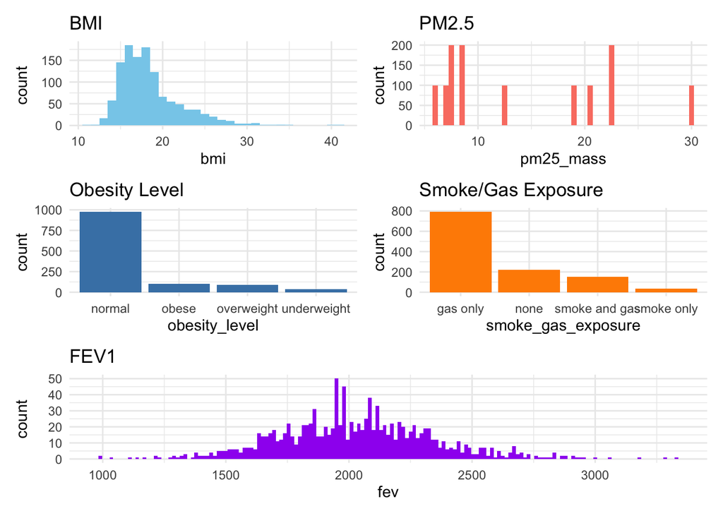

```r
p1 <- ggplot(chs, aes(x = bmi)) +
  geom_histogram(binwidth = 1, fill = "skyblue") +
  theme_minimal() +
  labs(title = "BMI")

p2 <- ggplot(chs, aes(x = pm25_mass)) +
  geom_histogram(binwidth = 0.5, fill = "salmon") +
  theme_minimal() +
  labs(title = "PM2.5")

p3 <- ggplot(chs, aes(x = obesity_level)) +
  geom_bar(fill = "steelblue") +
  theme_minimal() +
  labs(title = "Obesity Level")

p4 <- ggplot(chs, aes(x = smoke_gas_exposure)) +
  geom_bar(fill = "darkorange") +
  theme_minimal() +
  labs(title = "Smoke/Gas Exposure")

p5 <- ggplot(chs, aes(x = fev)) +
  geom_histogram(binwidth = 15, fill = "purple") +
  theme_minimal() +
  labs(title = "FEV1")

(p1 | p2) / (p3 | p4) / p5
```

BMI is skewed right with more higher values. This is reflected in obesity level as well: most cases are normal, but very few are underweight. PM2.5 ranges from about 0 to 30; no distribution can be identified as only limited discrete values are represented. Most individuals are only exposed to gas, and the least are exposed to smoke alone. FEV1 is approximately normally distributed with a center of about 2000 and range from 1000 to 3000. This means it is an appropriate response variable for linear regression.

```r
bmi_lm <- lm(data=chs, fev~bmi)
summary(bmi_lm)
```

```
Call:
lm(formula = fev ~ bmi, data = chs)

Residuals:
    Min      1Q  Median      3Q     Max
-989.47 -193.88  -11.32  179.43 1305.46

Coefficients:
            Estimate Std. Error t value Pr(>|t|)
(Intercept)  1452.46      44.49   32.65   <2e-16 ***
bmi            31.23       2.36   13.23   <2e-16 ***
---
Signif. codes:  0 '***' 0.001 '**' 0.01 '*' 0.05 '.' 0.1 ' ' 1

Residual standard error: 297.2 on 1198 degrees of freedom
Multiple R-squared:  0.1275,    Adjusted R-squared:  0.1268
F-statistic: 175.1 on 1 and 1198 DF,  p-value: < 2.2e-16
```

There is a statistically significant association (p<0.05) between bmi an fev1. A 1 point higher bmi corresponds, on average to a 31.23 higher fev value.

```r
smoke_gas_lm <- lm(data=chs, fev~smoke_gas_exposure)
summary(smoke_gas_lm)
```

```
Call:
lm(formula = fev ~ smoke_gas_exposure, data = chs)

Residuals:
    Min      1Q  Median      3Q     Max
-1037.8  -205.3   -12.0   190.7  1301.0

Coefficients:
                                Estimate Std. Error t value Pr(>|t|)
(Intercept)                     2022.671     11.310 178.836   <2e-16 ***
smoke_gas_exposurenone            34.023     24.289   1.401    0.162
smoke_gas_exposuresmoke and gas    2.107     28.017   0.075    0.940
smoke_gas_exposuresmoke only      33.043     54.209   0.610    0.542
---
Signif. codes:  0 '***' 0.001 '**' 0.01 '*' 0.05 '.' 0.1 ' ' 1

Residual standard error: 318.1 on 1196 degrees of freedom
Multiple R-squared:  0.001868,  Adjusted R-squared:  -0.0006354
F-statistic: 0.7462 on 3 and 1196 DF,  p-value: 0.5246
```

There is no statistically significant association between smoke and/or gas exposure and fev values.

```r
pm_lm <- lm(data=chs, fev~pm25_mass)
summary(pm_lm)
```

```
Call:
lm(formula = fev ~ pm25_mass, data = chs)

Residuals:
     Min       1Q   Median       3Q      Max
-1070.63  -206.57   -13.33   195.87  1277.65

Coefficients:
            Estimate Std. Error t value Pr(>|t|)
(Intercept) 2073.452     19.309 107.383   <2e-16 ***
pm25_mass     -3.016      1.184  -2.548    0.011 *
---
Signif. codes:  0 '***' 0.001 '**' 0.01 '*' 0.05 '.' 0.1 ' ' 1

Residual standard error: 317.3 on 1198 degrees of freedom
Multiple R-squared:  0.005389,  Adjusted R-squared:  0.004559
F-statistic: 6.492 on 1 and 1198 DF,  p-value: 0.01096
```

There is a marginally significant association (p=0.011) between surrounding pm2.5 levels and fev1. A 1 point higher pm2.5 mass corresponds, on average to a 3.016 lower fev value.

# Visualizations

1. Facet plot showing scatterplots with regression lines of BMI vs FEV by “townname”.

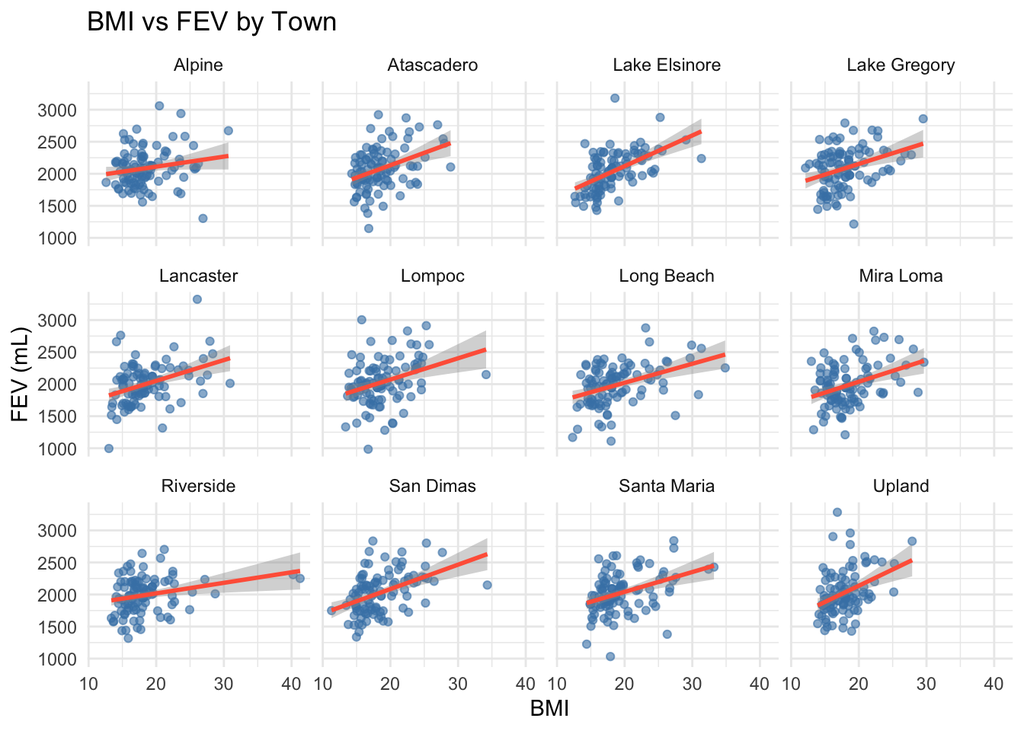

   ```r
   ggplot(chs, aes(x = bmi, y = fev)) +
     geom_point(alpha = 0.6, color = "steelblue") +
     geom_smooth(method = "lm", se = TRUE, color = "tomato") +
     facet_wrap(~ townname) +
     labs(
       title = "BMI vs FEV by Town",
       x = "BMI",
       y = "FEV (mL)"
     ) +
     theme_minimal()
   ```

   Across all towns, FEV tends to increase with BMI. Most points are clustered at a relatively low BMI and FEV.
2. Stacked histograms of FEV by BMI category and FEV by smoke/gas exposure. Use different color schemes than the ggplot default.

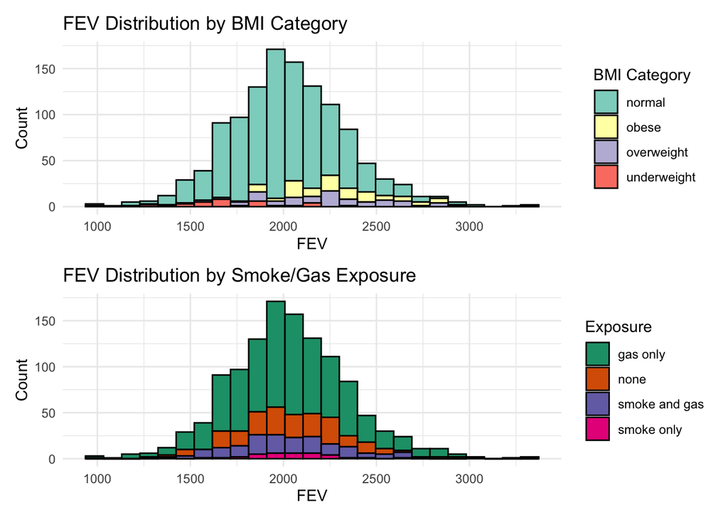

   ```r
   p1 <- ggplot(chs, aes(x = fev, fill = obesity_level)) +
     geom_histogram(position = "stack", bins = 25, color = "black") +
     scale_fill_brewer(palette = "Set3") +
     labs(
       title = "FEV Distribution by BMI Category",
       x = "FEV",
       y = "Count",
       fill = "BMI Category"
     ) +
     theme_minimal()

   p2 <- ggplot(chs, aes(x = fev, fill = smoke_gas_exposure)) +
     geom_histogram(position = "stack", bins = 25, color = "black") +
     scale_fill_brewer(palette = "Dark2") +
     labs(
       title = "FEV Distribution by Smoke/Gas Exposure",
       x = "FEV",
       y = "Count",
       fill = "Exposure"
     ) +
     theme_minimal()
   p1/p2
   ```

   FEV is approximately normally distributed. From this graph there does not appear to be a clear association between BMI category or Smoke/Gas exposure and FEV levels. The overwhelming majority of individuals have a normal BMI. Most individuals were exposed to gas only, but the distribution appears to be a bit more even.
3. Barchart of BMI by smoke/gas exposure.

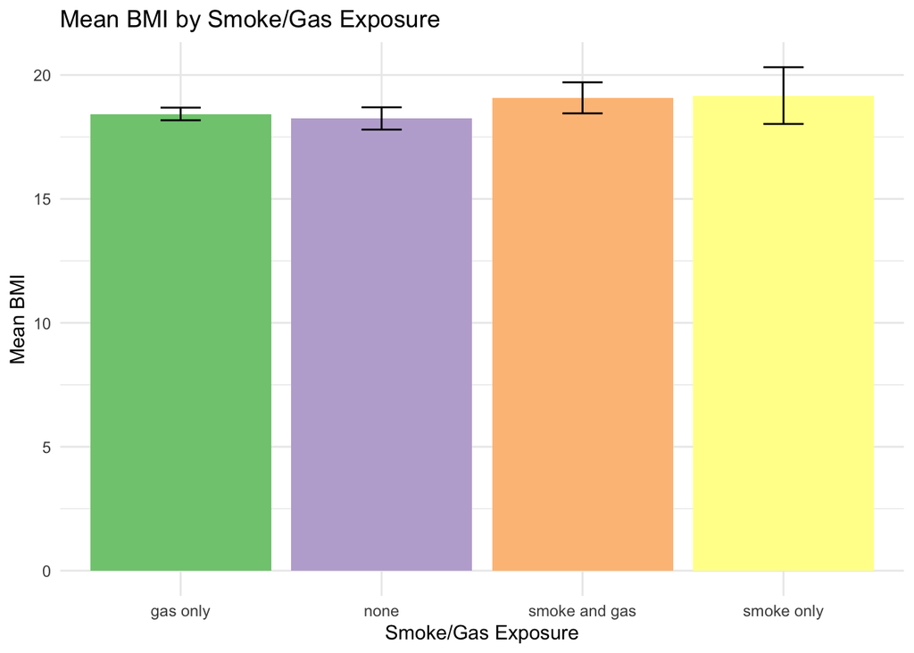

   ```r
   ggplot(chs, aes(x = smoke_gas_exposure, y = bmi, fill = smoke_gas_exposure)) +
     stat_summary(fun = mean, geom = "bar") +
     stat_summary(fun.data = mean_cl_normal, geom = "errorbar", width = 0.2) +
     scale_fill_brewer(palette='Accent') +
     labs(
       title = "Mean BMI by Smoke/Gas Exposure",
       x = "Smoke/Gas Exposure",
       y = "Mean BMI"
     ) +
     theme_minimal() +
     theme(legend.position = "none")
   ```

   It appears that individuals with smoke exposure (including smoke and gas exposure) have on average a higher BMI than those with no smoke exposure (gas only or no exposure). This indicates that there may be some confounding variables — the effect of smoke and or gas exposure on FEV may be related to its effect on BMI instead of FEV directly.
4. Statistical summary graphs of FEV by BMI and FEV by smoke/gas exposure category.

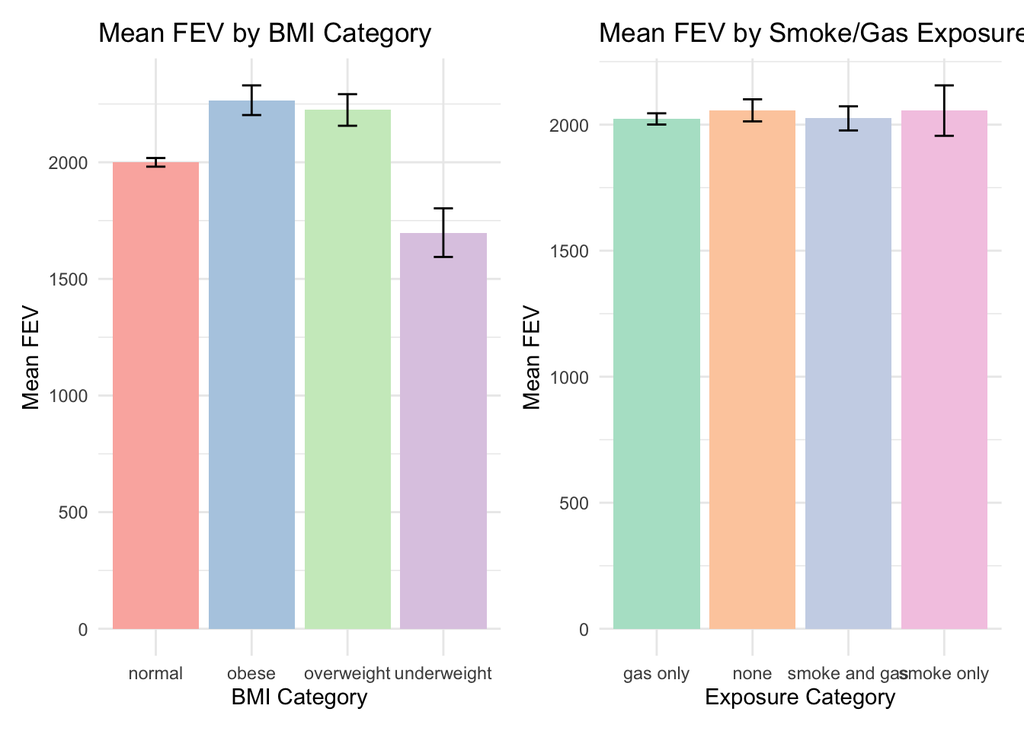

   ```r
   p1 <- ggplot(chs, aes(x = obesity_level, y = fev, fill = obesity_level)) +
     stat_summary(fun = mean, geom = "bar") +
     stat_summary(fun.data = mean_cl_normal, geom = "errorbar", width = 0.2) +
     scale_fill_brewer(palette = "Pastel1") +
     labs(
       title = "Mean FEV by BMI Category",
       x = "BMI Category",
       y = "Mean FEV"
     ) +
     theme_minimal() +
     theme(legend.position = "none")
   p2 <- ggplot(chs, aes(x = smoke_gas_exposure, y = fev, fill = smoke_gas_exposure)) +
     stat_summary(fun = mean, geom = "bar") +
     stat_summary(fun.data = mean_cl_normal, geom = "errorbar", width = 0.2) +
     scale_fill_brewer(palette = "Pastel2") +
     labs(
       title = "Mean FEV by Smoke/Gas Exposure",
       x = "Exposure Category",
       y = "Mean FEV"
     ) +
     theme_minimal() +
     theme(legend.position = "none")
   p1|p2
   ```

   Generally mean fev increases with increasing weight category. However, obese and overweight indivduals have very similar mean fev values, indicating that the effect may be reduced once a certain bmi is reached.

   There does not appear to be a significant difference in mean FEV based on smoke and/or gas exposure.
5. A leaflet map showing the concentrations of PM2.5 mass in each of the CHS communities.

   ```r
   town_summary <- chs %>%
     group_by(townname, lat, lon) %>%
     summarise(pm25_mean = mean(pm25_mass, na.rm = TRUE), .groups = "drop")

   pal <- colorNumeric("YlOrRd", domain = town_summary$pm25_mean)

   leaflet(town_summary) %>%
     addTiles() %>%
     addCircleMarkers(
       ~lon, ~lat,
       radius = 8,
       color = ~pal(pm25_mean),
       fillOpacity = 0.8,
       popup = ~paste0(townname, "<br>PM2.5: ", round(pm25_mean, 2))
     ) %>%
     addLegend("bottomright",
               pal = pal,
               values = ~pm25_mean,
               title = "Mean PM2.5")
   ```

[interactive chart not shown]

   Mira Loma has the highest PM2.5 levels and higher levels tend to be near there. Towns further away from Los Angelos have lower mean PM2.5 levels. This makes sense that the city has lower air quality due to greater traffic volume
6. Choose a visualization to examine whether PM2.5 mass is associated with FEV.

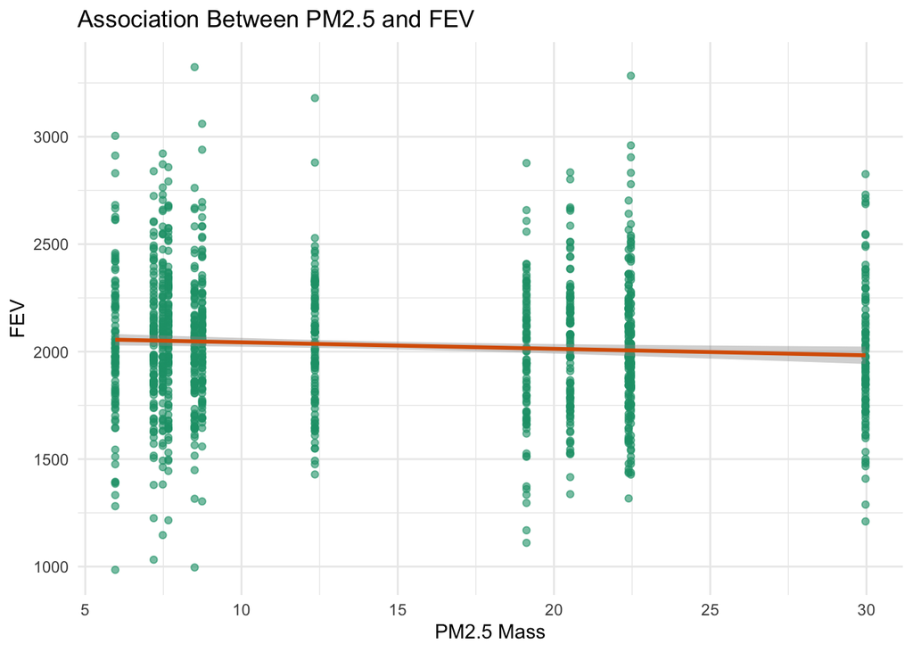

```r
ggplot(chs, aes(x = pm25_mass, y = fev)) +
  geom_point(alpha = 0.6, color = "#1B9E77") +
  geom_smooth(method = "lm", se = TRUE, color = "#D95F02") +
  labs(
    title = "Association Between PM2.5 and FEV",
    x = "PM2.5 Mass",
    y = "FEV"
  ) +
  theme_minimal()
```

Generally, fev decreases with increasing PM2.5 levels. However, it is difficult to determine due to limited values for PM2.5. Our analysis is limited by only having one value per town. (12 values total). Our analysis can be furthered by obtaining more local PM2.5 levels to better determine if FEV and PM2.5 are associated.